# Time Series Analysis

## Twin Cities Nice Ride Analysis

### Authors: Khoi Dang, Joel Resler, Quentin Smith

### Date: 5/1/2020

# Table of Contents:

1. Introduction
   - What is Forecasting
   - Example
   - Overview of Problem
2. Data
   - Question 1:
     - EDA
     - Model
       - ARIMA
       - SARIMA
       - FB Prophet
     - Conclusion Question 1
   - Question 2:
     - EDA
     - Model
     - Conclusion Question 2
   - Question 3:
     - EDA
     - Model
     - Conclusion Question 3
3. Conclusion
4. Resources

## What is Forecasting

**Forecasting** is predicting the future given all the information available which includes historical data and knowledge of any future events that might impact the forecast.

Examples of where forecasting is important:

```
- Short-term forecasting for scheduling employees, production and transportation.
- Medium-term forecasting for purchasing raw materials, hire personal, or buy machinery and equipment.
- Long-term forecasts for stategic planning.
```

Forecasting situation vary widely in their time horizons, factors detrmining actual outcome, types of data patterns, etc.

Types of forecasting methods are simple such as the naive method, which takes the most recent observation as a forecast, or complex methods such as neural nets. No matter what type of forecasting method is used complexity harms forecast accuracy by 25% [3]. So we need to choose the best forecasting method for our situation with as little complexity as possible to answer our questions.

## Let us try an Example

We will go through the basic steps of a forecasting task as outlined by Rob J Hyndman:

1. **Problem Definition/ Overview:**

   Define the problem and carefully decide the way the forecast will be used, who requires the forecast, and how the forecast function fits within the questions that are asked.
1. **Gathering Information:**

   Gather the statistical data. Good statistical models will handle evolutionary changes in the system; don't throw away good data unnecessarily. This will also be the step of data preprocessing.
1. **Exploratory Data Analysis:**

   Start by graphing the data and making note of any consistent patterns, significant trends, seasonality, outliers, and relationships between variables.
1. **Choosing and Fitting Models:**

   Choosing a model depends on the availability of historical data, strength of relationships between variables, and the way the forecasts are to be used. It is common to compare two or three potential models using train and test sets.
1. **Using and Evaluating a Forecasting Model:**

   Once a model is selected and its parameters estimated we can use the model to make forecasts. Then we will choose a method for assessing the accuracy of the forecast.

## Overview of Problem

### Quantitative Forecasting vs Qualitative Forecasting:

**Qualitative forecasting** is used when data is scarce. It uses human judgement and rating schemes to turn qualitative information into quantitative [4]. Some techniques include the Delphi method, Market research, or Panel Cansensus.

**Quantitative Forecasting models:** There are three types of models to describe quantitative forecasting.

1. **Explanatory Model** assumes that the variable to be forecast exhibits an explanatory relationship with one of more other variables called predictor variables [2]. Using the example problem above, if we were trying to forecast the yearly bike usage of Nice Ride's bike program (BU), we might use predictor variables, temperature, time of day, and events in city, such that:

Explanatory Model Equation/ Causal Method

$BU = f(temperature, time of day, events in city, error)$

1. **Time Series Model** uses only information on the variable to be forecast, bike usage (BU) just like in the case above, and makes no attempt to discover the factors affecting it's behavior [2]. Let it be the present time (hour, day, week) so:

Time Series Analysis Model Equation

$BU_{t+1} = f(BU_{t}, BU_{t-1}, ... , BU_{t-n}, error)$

1. **Mixed Model/Dynamic Regression Models** uses both the explanatory model and the time series model. An equation for our example could be such that:

Dynamic Regression Model Equation

$BU_{t+1} = f(BU_t, current temperature, time of day, events in city, error)$

### Example Problem

In 2010, Minneapolis and St. Paul became one of the nation's first cities to implement a bicycle-sharing program. It started with 700 bicycles and 65 stations [https://www.niceridemn.com/about]. Currently, there are 3000+ bikes and 400+ stations across the Twin Cities. Nice Ride bike share was designed for quick trips and convenience.

Bike shares are an interesting topic for us and we are interested in Nice Ride's future outlook and how they have done thus far. A few questions we are going to investigate are:

1. What is the overall bike usage for each year and the predicted usage for future years?
2. What is the typical duration of a trip? Should we change how we charge people, either per trip or by duration?
3. What stations are the most frequent starting points for trips? Should we add more bikes at the frequent starting point or should we remove bikes at the frequent starting point?

The first question uses one variable to predict the future outlook. This would be an example of a Time Sereies Model. The time series variable used in the first question will be bike usage which we will define as any trip with any duration of time used.

The second question uses a mixed model or dynamic regression model.

The second question will use duration as the main variable for time series with the predictor variable being an outside variable cost. We will be using their cost outline found at https://www.niceridemn.com/pricing and the membership type/account type.

The third question will use one variable to predict the future outlook. This would be another example of a Time Series Model. The time series variable will be the frequency of start stations per day.

```python
#Tools needed
from   collections import Counter
import datetime
from   fnmatch import fnmatch
from   fbprophet import Prophet
import itertools
import logging
logging.getLogger().setLevel(logging.ERROR)
import matplotlib.pyplot as plt
import numpy as np
import os
import pandas as pd
from   pandas import DataFrame
import pickle
import re
import seaborn as sns
from   sklearn.metrics import mean_squared_error
import statsmodels.api as sm
from   statsmodels.tsa.arima_model import ARIMA
import warnings
warnings.filterwarnings("ignore")

%matplotlib inline

# Reload data from source (True) or use pickled data (False)
RELOAD = False
```

```
Importing plotly failed. Interactive plots will not work.
```

```python
#conda install -c conda-forge fbprophet
```

# Data Preparation import from CSV files

The NiceRide bikeshare data was acquired from: https://www.niceridemn.com/system-data Visually exploring the csv files we can see there is:

**Ride data attributes:**

- Start date
- Start station
- Start terminal
- End date
- End station
- End terminal
- Total duration (ms)
- Account type
- Bike Type *(used when dockless bikes become available in 2018)*

Because of the large dataset, we will reduce the number of variables during our data preprocessing.

We will keep the following variables

**Ride data attributes:**

- Start date
- Start station
- End date
- End station
- Total duration (ms) or Total duration (sec) *(change from ms to sec in 2015)*
- Account type
- Bike Type *(used when dockless bikes become available in 2018)*

### Some information about our csv files, when manually checking:

1) There are 32 csv_files, which:

- 8 csv_files contain trips information from 2010-2017: ends with *'season.csv'*
- 8 csv files contain station information from 2010-2017: ends with *'locations.csv'*
- 16 csv files contain monthly trip information of year 2018 and year 2019: end with *'tripdata.csv'*

2) Inconsistencies in column names in units in 8 csv_files (ends with *'season.csv'*) of trip information from 2010-2017

- Total duration (ms): 2010, 2011, 2012, 2013, 2014
- Total duration (Seconds): 2015, 2017
- Total duration (seconds): 2016

*Resolution: First, convert all values in 2010-2014 dataframe from ms to seconds. Then change all column name to 'Total duration (Seconds)'*

3) Columns name change from 2018

- Start date -> start_time
- Start station -> start station name
- End date ->end_time
- End station -> end station name
- Total duration (Seconds) -> trip duration (in seconds)
- Account type -> usertype
- *NEW COLUMN*: bike type *(used when dockless bikes become available in 2018)*

```python
def list_files(path):
    csv_file = []
    pattern = "*.csv"

    for path, subdirs, files in os.walk(path):
        for name in files:
            if fnmatch(name, pattern):
                csv_file.append(os.path.join(path, name))
    return csv_file

my_csv_file=list_files('data/')
print(len(my_csv_file))
```

```
32
```

```python
## Function to check columns name of all dataframe
def check_columns(data_frame):
    col_namelist = []

    df = pd.read_csv(data_frame)
    for col in df.columns:
        col_namelist.append(col)
    return col_namelist
```

# Data Preprocessing - Really important

```python
## Extract training list from 2010 - 2017, taking csv files with trip duration only
## This part to answer question on the seasonality of biker services.
## Question: What is the bike usage for each year, and how would the prediction for future

training_list = []
for items in my_csv_file:
    if items.endswith('season.csv'):
        training_list.append(items)

## Sort the list
print(len(training_list))
training_list.sort()
```

```
8
```

## Data Preprocessing for training set (from 2010 to 2017)

```python
## Read csv file for year 2010-2017
## Convert from ms to seconds, then change columns name to 'Total duration (Seconds)' if possible.

df1 = pd.read_csv(training_list[0])
df1 = df1.dropna()
df1['Total duration (ms)'] = 1e-3 * df1['Total duration (ms)']
df1 = df1.rename(columns={'Total duration (ms)': 'Total duration (Seconds)'})


for i in range(1,len(training_list)):
    df2 = pd.read_csv(training_list[i])
    df2 = df2.dropna()
    column_list = check_columns(training_list[i])
    if column_list[6] == 'Total duration (ms)':
        df2['Total duration (ms)'] = 1e-3 * df2['Total duration (ms)']
        df2 = df2.rename(columns={'Total duration (ms)': 'Total duration (Seconds)'})
        df1 = df1.append(df2)
    elif column_list[6] == 'Total duration (seconds)':
        df2 = df2.rename(columns={'Total duration (seconds)': 'Total duration (Seconds)'})
        df1 = df1.append(df2)
    else:
        df1 = df1.append(df2)

## Rename our dataframe, prepare for analysis later:
data_from2010 = df1[['Start date','Start station','End date','End station','Total duration (Seconds)',
                     'Account type']]
print(data_from2010.head())
data_from2010.tail()
```

```
        Start date       Start station         End date  \
0   6/10/2010 8:01  100 Main Street SE   6/10/2010 8:01
1  6/10/2010 17:38  100 Main Street SE  6/10/2010 17:54
2  6/10/2010 21:15  100 Main Street SE  6/10/2010 21:27
3  6/11/2010 13:52  100 Main Street SE  6/11/2010 14:42
4  6/11/2010 15:20  100 Main Street SE  6/11/2010 16:11

              End station  Total duration (Seconds) Account type
0      100 Main Street SE                     8.018       Casual
1              IDS Center                   963.762       Casual
2  11th Street & Hennepin                   717.079       Casual
3  Washington & 2nd Ave N                  2966.016       Casual
4             Blegen Hall                  3040.238       Casual
```

|  | Start date | Start station | End date | End station | Total duration (Seconds) | Account type |
| --- | --- | --- | --- | --- | --- | --- |
| 460713 | 04-03-17 09:45 | Grant Street & Portland Ave | 04-03-17 09:50 | Hennepin County Government Center | 340.0 | Member |
| 460714 | 04-03-17 09:46 | Portland Ave & Washington Ave | 04-03-17 09:55 | 4th Street S & 19th Ave | 571.0 | Member |
| 460715 | 04-03-17 09:41 | 2nd Ave S & S 3rd Street | 04-03-17 10:13 | Grant Street & Portland Ave | 1887.0 | Member |
| 460716 | 04-03-17 09:27 | Marshall Street NE & 8th Ave NE | 04-03-17 09:36 | 2nd Ave S & S 3rd Street | 532.0 | Member |
| 460717 | 04-03-17 09:19 | Portland Ave & Washington Ave | 04-03-17 09:25 | Currie Park | 361.0 | Member |

## Data Preprocessing for testing set (from 2018 to 2019)

```python
## Preprocessing data for Testing
testing_list = []
for items in my_csv_file:
    if items.endswith('tripdata.csv'):
        testing_list.append(items)

## Sort the list
testing_list.sort()

print(len(testing_list))
```

```
16
```

```python
## Read csv file for year 2018, choosing Start date, and End date columns for analysis
df1 = pd.read_csv(testing_list[0])
df1 = df1.dropna()
# append year from 2018-2019 to df1, create final testing dataset:
for i in range(1,len(testing_list)):
    df2 = pd.read_csv(testing_list[i])
    df2 = df2.dropna()
    df1 = df1.append(df2,ignore_index=True)

## Rename our dataframe, choose necessary column for our analysis, and prepare for analysis later:
data_from2018 = df1[['start_time','start station name','end_time','end station name',
                     'tripduration','usertype','bike type']]
print(data_from2018.head())
data_from2018.tail()
```

```
                 start_time             start station name  \
0  2018-04-24 16:03:04.2700               Boom Island Park
1  2018-04-24 16:38:40.5210             100 Main Street SE
2  2018-04-24 17:51:10.1450   North 2nd Street & 4th Ave N
3  2018-04-24 18:50:05.7390  Portland Ave & Washington Ave
4  2018-04-25 08:49:05.2720   North 2nd Street & 4th Ave N

                   end_time               end station name  tripduration  \
0  2018-04-24 16:25:57.6010             100 Main Street SE          1373
1  2018-04-24 17:07:31.1070   North 2nd Street & 4th Ave N          1730
2  2018-04-24 18:00:17.4510  Portland Ave & Washington Ave           547
3  2018-04-24 19:04:22.0360   North 2nd Street & 4th Ave N           856
4  2018-04-25 08:56:40.3060    Nicollet Mall & 10th Street           455

     usertype bike type
0    Customer   Classic
1    Customer   Classic
2  Subscriber   Classic
3  Subscriber   Classic
4  Subscriber   Classic
```

|  | start_time | start station name | end_time | end station name | tripduration | usertype | bike type |
| --- | --- | --- | --- | --- | --- | --- | --- |
| 662144 | 2019-11-17 21:37:11.3760 | Central Ave NE & 22nd Ave NE | 2019-11-17 21:47:27.1760 | Marshall Street NE & 8th Ave NE | 615 | Subscriber | Classic |
| 662145 | 2019-11-17 21:38:26.3840 | Park Ave & 4th Street S | 2019-11-19 14:06:56.4800 | NRM Bike Shop 2 | 145710 | Customer | Classic |
| 662146 | 2019-11-17 21:38:34.9960 | Franklin & 28th Ave | 2019-11-18 00:44:31.9570 | Beltrami Park | 11156 | Customer | Classic |
| 662147 | 2019-11-17 21:58:40.0730 | Gateway Park | 2019-11-17 22:05:39.2460 | Nicollet & Franklin | 419 | Subscriber | Classic |
| 662148 | 2019-11-17 22:01:09.7200 | Cooke Hall | 2019-11-17 22:10:11.6300 | SE 4th Street & SE 3rd Ave | 541 | Subscriber | Classic |

# EDA for Question 1:

```python
## Convert to datetime format as MM/YYYY
# JR - This takes a long time pickle it to make it faster
if RELOAD:
    data_from2010['Date'] = pd.to_datetime(data_from2010['Start date'], errors='coerce')
    data_from2010['Date'] = data_from2010['Date'].dt.strftime('%m/%d/%Y')
    data_from2010_fd = open(r"data\pickles\data_from2010.pkl", "wb")
    pickle.dump(data_from2010, data_from2010_fd)
else:
    data_from2010_fd = open(r"data\pickles\data_from2010.pkl", "rb")
    data_from2010 = pickle.load(data_from2010_fd)
data_from2010_fd.close()

data_from2010.head()
```

|  | Start date | Start station | End date | End station | Total duration (Seconds) | Account type | Date |
| --- | --- | --- | --- | --- | --- | --- | --- |
| 0 | 6/10/2010 8:01 | 100 Main Street SE | 6/10/2010 8:01 | 100 Main Street SE | 8.018 | Casual | 06/10/2010 |
| 1 | 6/10/2010 17:38 | 100 Main Street SE | 6/10/2010 17:54 | IDS Center | 963.762 | Casual | 06/10/2010 |
| 2 | 6/10/2010 21:15 | 100 Main Street SE | 6/10/2010 21:27 | 11th Street & Hennepin | 717.079 | Casual | 06/10/2010 |
| 3 | 6/11/2010 13:52 | 100 Main Street SE | 6/11/2010 14:42 | Washington & 2nd Ave N | 2966.016 | Casual | 06/11/2010 |
| 4 | 6/11/2010 15:20 | 100 Main Street SE | 6/11/2010 16:11 | Blegen Hall | 3040.238 | Casual | 06/11/2010 |

```python
## Extract Date information and convert it to list
## The next steps is to finalize data preprocessing
## Step 1: Extract date and convert to list of date
## Step 2: Count the number of unique values in the list and combine into dictionary
## Step 3: Convert dictionary to dataFrame, thus finish our data preprocessing

combine_data = data_from2010['Date'].values.tolist()

data_dict = Counter(combine_data)
new_data_from2010 = pd.DataFrame(data_dict.items(), columns=['Date', 'Number of Biker'])
new_data_from2010.head()
```

|  | Date | Number of Biker |
| --- | --- | --- |
| 0 | 06/10/2010 | 104 |
| 1 | 06/11/2010 | 287 |
| 2 | 06/12/2010 | 347 |
| 3 | 06/13/2010 | 385 |
| 4 | 06/14/2010 | 183 |

```python
## Convert to datetime format as MM/YYYY
data_from2018['Date'] = pd.to_datetime(data_from2018['start_time'], errors='coerce')
data_from2018['Date'] = data_from2018['Date'].dt.strftime('%m/%d/%Y')
data_from2018.head()
```

|  | start_time | start station name | end_time | end station name | tripduration | usertype | bike type | Date |
| --- | --- | --- | --- | --- | --- | --- | --- | --- |
| 0 | 2018-04-24 16:03:04.2700 | Boom Island Park | 2018-04-24 16:25:57.6010 | 100 Main Street SE | 1373 | Customer | Classic | 04/24/2018 |
| 1 | 2018-04-24 16:38:40.5210 | 100 Main Street SE | 2018-04-24 17:07:31.1070 | North 2nd Street & 4th Ave N | 1730 | Customer | Classic | 04/24/2018 |
| 2 | 2018-04-24 17:51:10.1450 | North 2nd Street & 4th Ave N | 2018-04-24 18:00:17.4510 | Portland Ave & Washington Ave | 547 | Subscriber | Classic | 04/24/2018 |
| 3 | 2018-04-24 18:50:05.7390 | Portland Ave & Washington Ave | 2018-04-24 19:04:22.0360 | North 2nd Street & 4th Ave N | 856 | Subscriber | Classic | 04/24/2018 |
| 4 | 2018-04-25 08:49:05.2720 | North 2nd Street & 4th Ave N | 2018-04-25 08:56:40.3060 | Nicollet Mall & 10th Street | 455 | Subscriber | Classic | 04/25/2018 |

```python
## Extract Date information and convert it to list
## The next steps is to finalize data preprocessing
## Step 1: Extract date and convert to list of date
## Step 2: Count the number of unique values in the list and combine into dictionary
## Step 3: Convert dictionary to dataFrame, thus finish our data preprocessing

combine_data = data_from2018['Date'].values.tolist()
data_dict = Counter(combine_data)
new_data_from2018 = pd.DataFrame(data_dict.items(), columns=['Date', 'Number of Biker'])
new_data_from2018.tail()
```

|  | Date | Number of Biker |
| --- | --- | --- |
| 412 | 11/13/2019 | 202 |
| 413 | 11/14/2019 | 202 |
| 414 | 11/15/2019 | 366 |
| 415 | 11/16/2019 | 279 |
| 416 | 11/17/2019 | 192 |

```python
## Combine both data to create final large dataset:
## From here, we have finish gather data for preprocessing.
## Next step is to analyze for time series
final_data = new_data_from2010.append(new_data_from2018)
print(final_data)
```

```
           Date  Number of Biker
0    06/10/2010              104
1    06/11/2010              287
2    06/12/2010              347
3    06/13/2010              385
4    06/14/2010              183
..          ...              ...
412  11/13/2019              202
413  11/14/2019              202
414  11/15/2019              366
415  11/16/2019              279
416  11/17/2019              192

[2084 rows x 2 columns]
```

```python
# Note: Even though we have finished data preprocessing, we still stumble into one minor problem.

## Our final_data rarely has any data (from 2010-2019) for Date and Number of Biker from December-March ,
## When we run Time series, it is possible that we can misjudge our prediction,
## My resolution that we will store all our final_data into a dictionary (let's call it my_result)
## Then we will create a new list(let's call it full_date_list) range from 2010-06-01 to 2019-11-01 on daily frequency
## Then we will try to pattern matching our value in the list with keys in our stored dictionary.
## If there is a match, we will store both the keys and values of our stored dictionary into a NEW dictionary.
## If there is no match, we will use our values as the key, and values is zero:

## Example:
## my_dict = {'a':1,'b':2}
## my_list = [a,b,c]
## return: new_dict = {'a':1,'b':2,'c':0}
```

```python
## Function to store a new dictionary

def convert_to_new_dict(my_dict,my_list):
    new_dict = {}
    for values in my_list:
        if values in my_dict.keys():
            new_dict[values]=my_dict[values]
        else:
            new_dict[values]= 0
    return new_dict
```

```python
# Extact all necessary in our final_data dataframe to create a dictionary
# In my case, I extracted these dataframe to answer the First Question
# 1) What is the overall bike usage for each year and the predicted usage for future year?

# Extract info
date_info = pd.Series(final_data['Date'].unique()).tolist()
biker_info = pd.Series(final_data['Number of Biker']).tolist()

## Convert dataframe to dictionary
my_result = dict(zip(date_info, biker_info))
```

```python
# Create a list of date range from '2010-06-01' to '2019-11-01'
full_date_list = pd.date_range('2010-06-01','2019-11-01',freq='D').strftime("%m/%d/%Y").tolist()
```

```python
## Calling our function to convert into new dictionary

sol_data = convert_to_new_dict(my_result,full_date_list)
```

```python
# Create a complete new data from our dictionary, from this, we have all date info, note that some of them
# the biker usage will contain 0.

final_data = pd.DataFrame(sol_data.items(), columns=['Date', 'Number of Biker'])

# Change to the right datetime format for Time Series
final_data['Date'] = pd.to_datetime(final_data.Date)
final_data.sort_values(by=['Date'],inplace = True)
final_data.head(20)
```

|  | Date | Number of Biker |
| --- | --- | --- |
| 0 | 2010-06-01 | 0 |
| 1 | 2010-06-02 | 0 |
| 2 | 2010-06-03 | 0 |
| 3 | 2010-06-04 | 0 |
| 4 | 2010-06-05 | 0 |
| 5 | 2010-06-06 | 0 |
| 6 | 2010-06-07 | 1 |
| 7 | 2010-06-08 | 2 |
| 8 | 2010-06-09 | 7 |
| 9 | 2010-06-10 | 104 |
| 10 | 2010-06-11 | 287 |
| 11 | 2010-06-12 | 347 |
| 12 | 2010-06-13 | 385 |
| 13 | 2010-06-14 | 183 |
| 14 | 2010-06-15 | 392 |
| 15 | 2010-06-16 | 519 |
| 16 | 2010-06-17 | 357 |
| 17 | 2010-06-18 | 569 |
| 18 | 2010-06-19 | 643 |
| 19 | 2010-06-20 | 604 |

# What is the overall bike usage for each year

```python
q1_answer = final_data.set_index(['Date'])

q1_res = q1_answer['Number of Biker'].resample('YS').sum()
q1_res.sum()
```

```
3352030
```

So from 2010-2019, Nice Ride Minnesota has carried out *3,352,030 Riderships*

### Average Ridership each year

```python
q1_res = q1_answer['Number of Biker'].resample('YS').mean().round()
q1_res.head(12)
```

```
Date
2010-01-01     474.0
2011-01-01     597.0
2012-01-01     750.0
2013-01-01     846.0
2014-01-01    1138.0
2015-01-01    1324.0
2016-01-01    1181.0
2017-01-01    1262.0
2018-01-01    1093.0
2019-01-01     849.0
Freq: AS-JAN, Name: Number of Biker, dtype: float64
```

# Prediction for usage in future years

# ARIMA and SARIMA comparison

```python
this_data = final_data.set_index(['Date'])
```

```python
y = this_data['Number of Biker'].resample('MS').mean()
print(len(y))
```

```
114
```

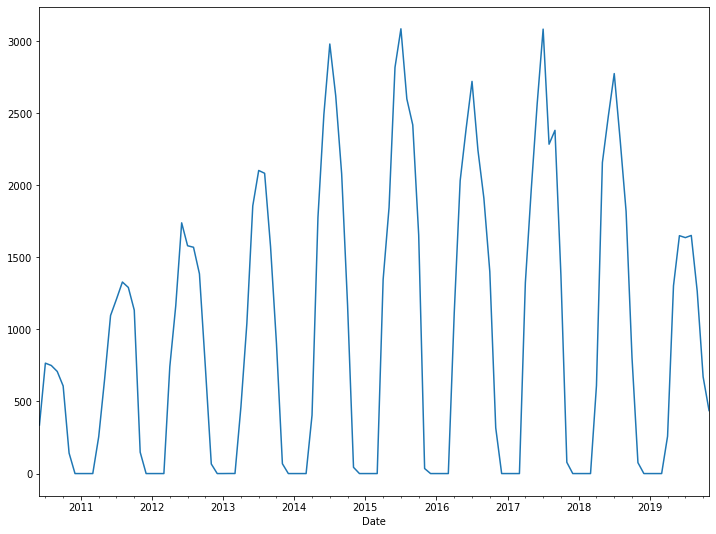

```python
pd.plotting.register_matplotlib_converters()
y.plot(figsize=(12, 9))
plt.show()
```

### Choosing parameter to tune in the time series

```python
p = d = q = range(0, 2)
pdq = list(itertools.product(p, d, q))
seasonal_pdq = [(x[0], x[1], x[2], 12) for x in list(itertools.product(p, d, q))]

for param in pdq:
    for param_seasonal in seasonal_pdq:
        try:
            mod = sm.tsa.statespace.SARIMAX(y,order=param,seasonal_order=param_seasonal, enforce_stationarity=False,enforce_invertibility=False)
            results = mod.fit()
            print('ARIMA{}x{}12 - AIC:{}'.format(param,param_seasonal,results.aic))
        except:
            continue
```

```
ARIMA(0, 0, 0)x(0, 0, 0, 12)12 - AIC:1955.00445207412
ARIMA(0, 0, 0)x(0, 0, 1, 12)12 - AIC:1652.440346463242
ARIMA(0, 0, 0)x(0, 1, 0, 12)12 - AIC:1478.9413345347707
ARIMA(0, 0, 0)x(0, 1, 1, 12)12 - AIC:1301.2328307667572
ARIMA(0, 0, 0)x(1, 0, 0, 12)12 - AIC:1498.7297010872296
ARIMA(0, 0, 0)x(1, 0, 1, 12)12 - AIC:1481.6121072063818
ARIMA(0, 0, 0)x(1, 1, 0, 12)12 - AIC:1317.1865278674206
ARIMA(0, 0, 0)x(1, 1, 1, 12)12 - AIC:1297.947610754126
ARIMA(0, 0, 1)x(0, 0, 0, 12)12 - AIC:1823.88076811137
ARIMA(0, 0, 1)x(0, 0, 1, 12)12 - AIC:1563.9812829314671
ARIMA(0, 0, 1)x(0, 1, 0, 12)12 - AIC:1434.4404921800349
ARIMA(0, 0, 1)x(0, 1, 1, 12)12 - AIC:1263.3464386208298
ARIMA(0, 0, 1)x(1, 0, 0, 12)12 - AIC:1467.3233251758636
ARIMA(0, 0, 1)x(1, 0, 1, 12)12 - AIC:1437.1667618661438
ARIMA(0, 0, 1)x(1, 1, 0, 12)12 - AIC:1293.4240799771744
ARIMA(0, 0, 1)x(1, 1, 1, 12)12 - AIC:1264.4896462764677
ARIMA(0, 1, 0)x(0, 0, 0, 12)12 - AIC:1738.2053358640617
ARIMA(0, 1, 0)x(0, 0, 1, 12)12 - AIC:1506.7982957747545
ARIMA(0, 1, 0)x(0, 1, 0, 12)12 - AIC:1435.6583757094202
ARIMA(0, 1, 0)x(0, 1, 1, 12)12 - AIC:1258.2343067100398
ARIMA(0, 1, 0)x(1, 0, 0, 12)12 - AIC:1445.770870742753
ARIMA(0, 1, 0)x(1, 0, 1, 12)12 - AIC:1426.9262626034124
ARIMA(0, 1, 0)x(1, 1, 0, 12)12 - AIC:1274.019673497811
ARIMA(0, 1, 0)x(1, 1, 1, 12)12 - AIC:1256.252186739376
ARIMA(0, 1, 1)x(0, 0, 0, 12)12 - AIC:1696.0145810094878
ARIMA(0, 1, 1)x(0, 0, 1, 12)12 - AIC:1487.869638895456
ARIMA(0, 1, 1)x(0, 1, 0, 12)12 - AIC:1414.9885562291413
ARIMA(0, 1, 1)x(0, 1, 1, 12)12 - AIC:1243.6346854218393
ARIMA(0, 1, 1)x(1, 0, 0, 12)12 - AIC:1441.3653486602755
ARIMA(0, 1, 1)x(1, 0, 1, 12)12 - AIC:1411.5980758028745
ARIMA(0, 1, 1)x(1, 1, 0, 12)12 - AIC:1271.6207240442127
ARIMA(0, 1, 1)x(1, 1, 1, 12)12 - AIC:1245.5658351197005
ARIMA(1, 0, 0)x(0, 0, 0, 12)12 - AIC:1750.4666816771924
ARIMA(1, 0, 0)x(0, 0, 1, 12)12 - AIC:1517.3238160293931
ARIMA(1, 0, 0)x(0, 1, 0, 12)12 - AIC:1429.6867011053428
ARIMA(1, 0, 0)x(0, 1, 1, 12)12 - AIC:1258.7388216180257
ARIMA(1, 0, 0)x(1, 0, 0, 12)12 - AIC:1428.891023948237
ARIMA(1, 0, 0)x(1, 0, 1, 12)12 - AIC:1425.5838755911839
ARIMA(1, 0, 0)x(1, 1, 0, 12)12 - AIC:1258.5614026027945
ARIMA(1, 0, 0)x(1, 1, 1, 12)12 - AIC:1255.82443826764
```

[output cut: 9 more lines]

```
ARIMA(1, 1, 0)x(0, 0, 1, 12)12 - AIC:1499.1902511677301
ARIMA(1, 1, 0)x(0, 1, 0, 12)12 - AIC:1428.558879383546
ARIMA(1, 1, 0)x(0, 1, 1, 12)12 - AIC:1256.8032145006696
ARIMA(1, 1, 0)x(1, 0, 0, 12)12 - AIC:1427.233401817915
ARIMA(1, 1, 0)x(1, 0, 1, 12)12 - AIC:1424.9391304081992
ARIMA(1, 1, 0)x(1, 1, 0, 12)12 - AIC:1257.0978132829616
ARIMA(1, 1, 0)x(1, 1, 1, 12)12 - AIC:1252.6216622110214
ARIMA(1, 1, 1)x(0, 0, 0, 12)12 - AIC:1690.5874505576814
ARIMA(1, 1, 1)x(0, 0, 1, 12)12 - AIC:1486.748142471645
ARIMA(1, 1, 1)x(0, 1, 0, 12)12 - AIC:1407.9014504349082
ARIMA(1, 1, 1)x(0, 1, 1, 12)12 - AIC:1245.4933473538001
ARIMA(1, 1, 1)x(1, 0, 0, 12)12 - AIC:1429.1781487473763
ARIMA(1, 1, 1)x(1, 0, 1, 12)12 - AIC:1402.707930820767
ARIMA(1, 1, 1)x(1, 1, 0, 12)12 - AIC:1259.0393107456462
ARIMA(1, 1, 1)x(1, 1, 1, 12)12 - AIC:1247.4350526566457
```

So our optimal parameter for ARIMA and SARIMA model is

*ARIMA(1, 0, 1)x(1, 1, 1, 12)12 - AIC:1243.412477096746*

# Model for Time Series

### ARIMA model

```
==============================================================================
                 coef    std err          z      P>|z|      [0.025      0.975]
------------------------------------------------------------------------------
ar.L1          0.8666      0.048     18.076      0.000       0.773       0.961
ma.L1          0.4827      0.085      5.670      0.000       0.316       0.649
sigma2       2.26e+05    2.4e+04      9.407      0.000    1.79e+05    2.73e+05
==============================================================================
```

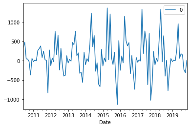

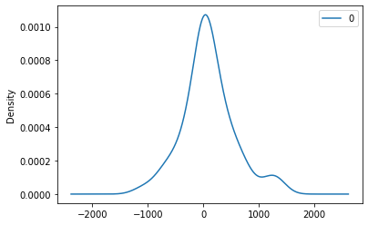

```
                 0
count   114.000000
mean     91.133748
std     467.411704
min   -1135.847894
25%    -110.114300
50%      42.406620
75%     304.908047
max    1361.649471
```

```python
# create ARIMA model
mod = sm.tsa.statespace.SARIMAX(y,
                                order=(1, 0 ,1),
                                enforce_stationarity=False,
                                enforce_invertibility=False)
results = mod.fit()
print(results.summary().tables[1])

# plot residual errors
residuals = DataFrame(results.resid)
residuals.plot()
plt.show()
residuals.plot(kind='kde')
plt.show()
print(residuals.describe())
```

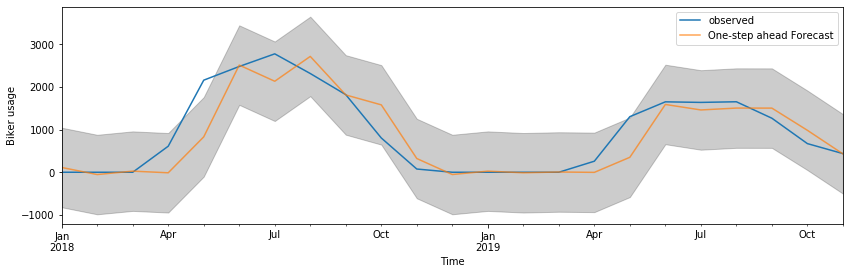

```python
pred = results.get_prediction(start=pd.to_datetime('2018-01-01'), dynamic=False)
pred_ci = pred.conf_int()
ax = y['2018':].plot(label='observed')
pred.predicted_mean.plot(ax=ax, label='One-step ahead Forecast', alpha=.7, figsize=(14, 4))
ax.fill_between(pred_ci.index,
                pred_ci.iloc[:, 0],
                pred_ci.iloc[:, 1], color='k', alpha=.2)
ax.set_xlabel('Time')
ax.set_ylabel('Biker usage')
plt.legend()
plt.show()
```

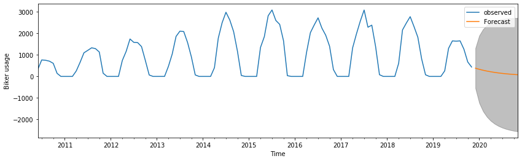

```python
pred_uc = results.get_forecast(steps=12)
pred_ci = pred_uc.conf_int()
ax = y.plot(label='observed', figsize=(14, 4))
pred_uc.predicted_mean.plot(ax=ax, label='Forecast')
ax.fill_between(pred_ci.index,
                pred_ci.iloc[:, 0],
                pred_ci.iloc[:, 1], color='k', alpha=.25)
ax.set_xlabel('Time')
ax.set_ylabel('Biker usage')
plt.legend()
plt.show()
```

```python
# Arima model predict from 2018-2019
arima_y_forecasted = pred.predicted_mean
arima_y_forecasted.head(12)
```

```
Date
2018-01-01     111.941263
2018-02-01     -54.028750
2018-03-01      26.077120
2018-04-01     -12.586192
2018-05-01     829.253151
2018-06-01    2510.747283
2018-07-01    2132.031316
2018-08-01    2714.402623
2018-09-01    1811.575720
2018-10-01    1579.027269
2018-11-01     321.588437
2018-12-01     -53.302049
Freq: MS, dtype: float64
```

```python
# Real value from dataset
y_truth = y['2018-01-01':]
y_truth.head(12)
```

```
Date
2018-01-01       0.000000
2018-02-01       0.000000
2018-03-01       0.000000
2018-04-01     610.100000
2018-05-01    2157.483871
2018-06-01    2478.300000
2018-07-01    2774.451613
2018-08-01    2313.645161
2018-09-01    1818.333333
2018-10-01     803.193548
2018-11-01      75.533333
2018-12-01       0.000000
Freq: MS, Name: Number of Biker, dtype: float64
```

```python
arima_y_forecasted = pred.predicted_mean
y_truth = y['2018-01-01':]
mse = mean_squared_error(y_truth, arima_y_forecasted, squared=False)

print('The Mean Squared Error is {}'.format(round(mse, 2)))
print('The Root Mean Squared Error is {}'.format(round(np.sqrt(mse), 2)))
```

```
The Mean Squared Error is 446.92
The Root Mean Squared Error is 21.14
```

```python
# Arima model monthly prediction for 2020
forecast = pred_uc.predicted_mean
forecast.head(12)
```

```
2019-12-01    381.565903
2020-01-01    330.664596
2020-02-01    286.553580
2020-03-01    248.327020
2020-04-01    215.199926
2020-05-01    186.492022
2020-06-01    161.613783
2020-07-01    140.054329
2020-08-01    121.370929
2020-09-01    105.179915
2020-10-01     91.148800
2020-11-01     78.989451
Freq: MS, dtype: float64
```

### Conclusion for ARIMA model:

These values seems decent, and will try SARIMA to see if we can achieve better result.

For the performance of Nice Ride Minnesota biker usage:

- First, our ARIMA model was able to forecast the trend, most of our biker usage are from April to October.
- For the prediction, seems like the prediction are terrible when using ARIMA, it predicted for the next 12 months, from 12/2019 to 11/2020, the services still keep going, and seem like data is skewed right.
- So the ARIMA fail to predict the seasonality, also it does not answer much how the biker services is going to be in the future.

### SARIMA model

```
==============================================================================
                 coef    std err          z      P>|z|      [0.025      0.975]
------------------------------------------------------------------------------
ar.L1          0.7227      0.112      6.460      0.000       0.503       0.942
ma.L1         -0.1410      0.178     -0.793      0.428      -0.489       0.207
ar.S.L12       0.3559      0.100      3.542      0.000       0.159       0.553
ma.S.L12      -1.0011     30.570     -0.033      0.974     -60.917      58.914
sigma2      5.775e+04   1.77e+06      0.033      0.974   -3.41e+06    3.52e+06
==============================================================================
```

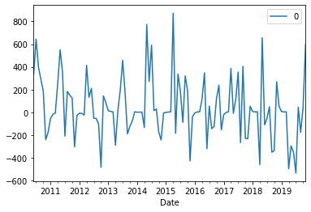

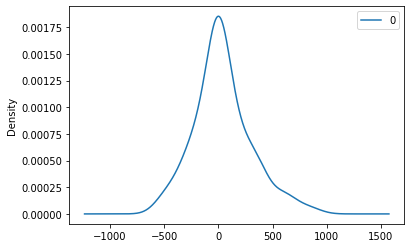

```
                0
count  114.000000
mean    39.642412
std    263.581017
min   -533.488051
25%   -107.606046
50%      4.682808
75%    181.653736
max    872.086721
```

```python
# create SARIMA model
mod = sm.tsa.statespace.SARIMAX(y,
                                order=(1, 0 ,1),
                                seasonal_order=(1, 1, 1, 12),
                                enforce_stationarity=False,
                                enforce_invertibility=False)
results = mod.fit()
print(results.summary().tables[1])

# plot residual errors
residuals = DataFrame(results.resid)
residuals.plot()
plt.show()
residuals.plot(kind='kde')
plt.show()
print(residuals.describe())
```

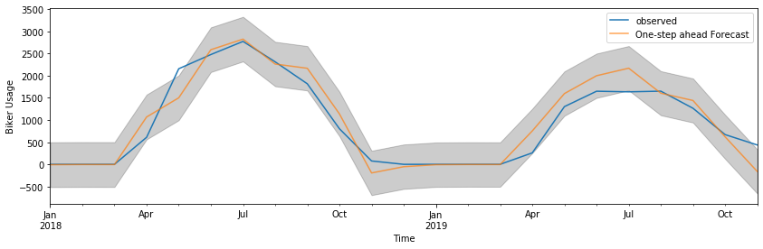

```python
pred = results.get_prediction(start=pd.to_datetime('2018-01-01'), dynamic=False)
pred_ci = pred.conf_int()
ax = y['2018':].plot(label='observed')
pred.predicted_mean.plot(ax=ax, label='One-step ahead Forecast', alpha=.7, figsize=(14, 4))
ax.fill_between(pred_ci.index,
                pred_ci.iloc[:, 0],
                pred_ci.iloc[:, 1], color='k', alpha=.2)
ax.set_xlabel('Time')
ax.set_ylabel('Biker Usage')
plt.legend()
plt.show()
```

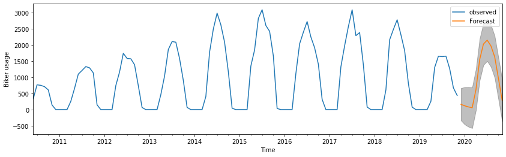

```python
pred_uc = results.get_forecast(steps=12)
pred_ci = pred_uc.conf_int()
ax = y.plot(label='observed', figsize=(14, 4))
pred_uc.predicted_mean.plot(ax=ax, label='Forecast')
ax.fill_between(pred_ci.index,
                pred_ci.iloc[:, 0],
                pred_ci.iloc[:, 1], color='k', alpha=.25)
ax.set_xlabel('Time')
ax.set_ylabel('Biker usage')
plt.legend()
plt.show()
```

```python
# Sarima model prediction for 2018-2019
sarima_y_forecasted = pred.predicted_mean
sarima_y_forecasted.head(12)
```

```
Date
2018-01-01      -8.440370
2018-02-01      -4.521606
2018-03-01      -5.406415
2018-04-01    1068.541165
2018-05-01    1501.507813
2018-06-01    2587.524136
2018-07-01    2826.207273
2018-08-01    2263.947716
2018-09-01    2168.250990
2018-10-01    1137.984072
2018-11-01    -194.584184
2018-12-01     -53.495462
Freq: MS, dtype: float64
```

```python
# Real value from dataset
y_truth.head(12)
```

```
Date
2018-01-01       0.000000
2018-02-01       0.000000
2018-03-01       0.000000
2018-04-01     610.100000
2018-05-01    2157.483871
2018-06-01    2478.300000
2018-07-01    2774.451613
2018-08-01    2313.645161
2018-09-01    1818.333333
2018-10-01     803.193548
2018-11-01      75.533333
2018-12-01       0.000000
Freq: MS, Name: Number of Biker, dtype: float64
```

```python
sarima_y_forecasted = pred.predicted_mean
y_truth = y['2018-01-01':]
mse = mean_squared_error(y_truth, sarima_y_forecasted, squared=False)

print('The Mean Squared Error is {}'.format(round(mse, 2)))
print('The Root Mean Squared Error is {}'.format(round(np.sqrt(mse), 2)))
```

```
The Mean Squared Error is 302.13
The Root Mean Squared Error is 17.38
```

```python
# Sarima model prediction for 2020
forecast = pred_uc.predicted_mean
forecast.tail(12)
```

```
2019-12-01     163.799719
2020-01-01     117.693815
2020-02-01      82.956936
2020-03-01      56.900146
2020-04-01     613.764333
2020-05-01    1544.849516
2020-06-01    2023.691642
2020-07-01    2145.545888
2020-08-01    1968.347122
2020-09-01    1630.952248
2020-10-01     962.844241
2020-11-01     281.486351
Freq: MS, dtype: float64
```

### Conclusion for SARIMA model:

These values seems decent, and recall to the ARIMA model

We are indeed achieving better result when running with SARIMA

For the performance of Nice Ride Minnesota biker usage:

- First, our SARIMA model was able to forecast the trend, most of our biker usage are from April to October.
- For the prediction, it predicts for the next 12 months, from 12/2019 to 11/2020, the biker usage are seasonality still popular during Aprip to October. Also, it predicts that the year 2020, the biker usage increases in number.
- So based on SARIMA, this services is promising in the future as the number of biker usage are increasing.

## FB Prophet model

```python
plt.style.use('fivethirtyeight')
```

```python
# Copy training and testing dataset
train, test = y[:'2017'], y['2018':]
print(train.tail())
test.head()
```

```
Date
2017-08-01    2284.580645
2017-09-01    2380.733333
2017-10-01    1377.129032
2017-11-01      78.133333
2017-12-01       0.000000
Freq: MS, Name: Number of Biker, dtype: float64
```

```
Date
2018-01-01       0.000000
2018-02-01       0.000000
2018-03-01       0.000000
2018-04-01     610.100000
2018-05-01    2157.483871
Freq: MS, Name: Number of Biker, dtype: float64
```

```python
# Copy our dataset for FB prophet model
q1_df = y.reset_index()
print(q1_df.tail())
q1_df.columns = ['ds', 'y']
q1_df.head()
```

```
          Date  Number of Biker
109 2019-07-01      1636.612903
110 2019-08-01      1651.612903
111 2019-09-01      1265.900000
112 2019-10-01       671.032258
113 2019-11-01       437.000000
```

|  | ds | y |
| --- | --- | --- |
| 0 | 2010-06-01 | 336.533333 |
| 1 | 2010-07-01 | 765.774194 |
| 2 | 2010-08-01 | 749.677419 |
| 3 | 2010-09-01 | 708.400000 |
| 4 | 2010-10-01 | 607.645161 |

```python
# Choosing the size for future prediction (monthly prediction)
prediction_size = 12
train_df = q1_df
```

```python
# Applying FB Prophet model
model = Prophet(seasonality_mode='multiplicative',weekly_seasonality=True,daily_seasonality=True)
model.fit(train_df)
```

```
<fbprophet.forecaster.Prophet at 0x28ebb3da408>
```

```python
# Train the original dataset
q1_future = model.make_future_dataframe(periods=prediction_size, freq='MS')
q1_forecast = model.predict(q1_future)
```

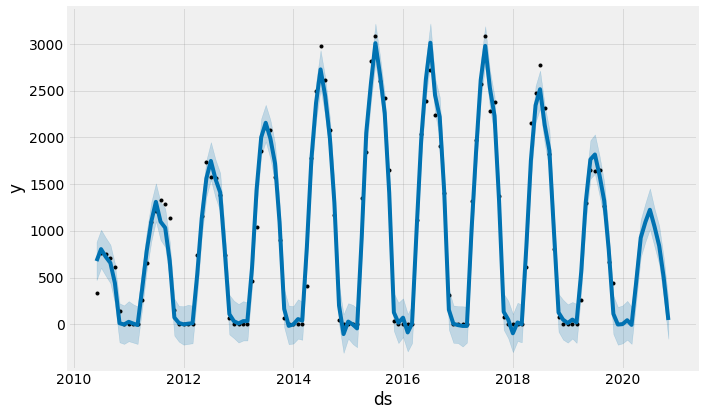

```python
# Plot the performance of FB Prophet
single_plot = model.plot(q1_forecast)
```

```python
## Visual comparison of FB Prohphet with testing dataset
```

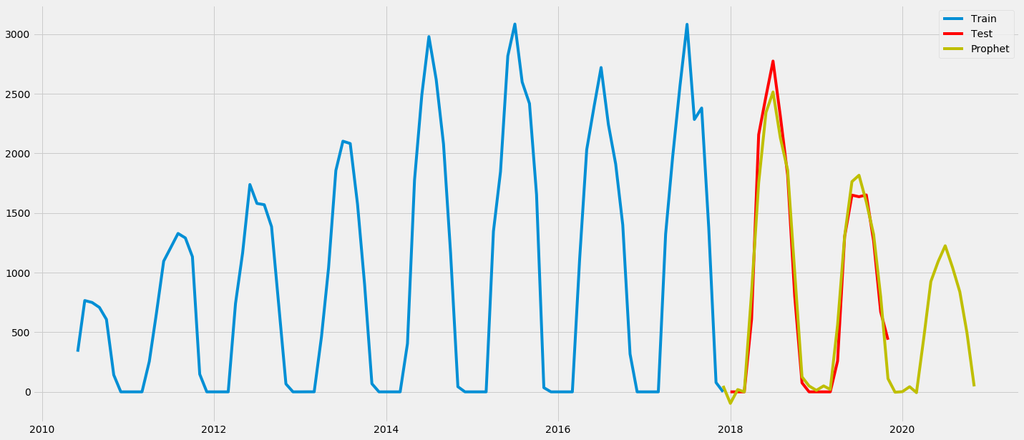

```python
plt.figure(figsize=(22, 10))
plt.plot(train.index, train, label='Train')
plt.plot(test.index, test, label='Test', color='r')
plt.plot(q1_forecast['ds'][90:], q1_forecast['yhat'][90:], label='Prophet', color='y')
plt.legend(loc='best', fontsize='medium')
plt.show()
```

```python
# yhat: the forecasted value of our metric (in Statistics,
# yhat is a notation traditionally used to represent the predicted values of a value y)

# Extract necesary information from FB prophet model:
# 'ds'-> contain monthly data; 'yhat'-> predicted value.
forecast_value = q1_forecast[['ds','yhat']]

# Extract data from 01/2018 to 11/2019 in FB Prophet model
forecast_2018_2019 = forecast_value[91:114]


print(forecast_2018_2019.head())
forecast_2018_2019.tail()
```

```
           ds         yhat
91 2018-01-01   -96.698929
92 2018-02-01    19.034562
93 2018-03-01    -0.000148
94 2018-04-01   837.275839
95 2018-05-01  1752.784653
```

|  | ds | yhat |
| --- | --- | --- |
| 109 | 2019-07-01 | 1816.719265 |
| 110 | 2019-08-01 | 1592.994686 |
| 111 | 2019-09-01 | 1320.785521 |
| 112 | 2019-10-01 | 798.788369 |
| 113 | 2019-11-01 | 110.798957 |

```python
# Real value from the dataset.
print(y_truth.head())
y_truth.tail()
```

```
Date
2018-01-01       0.000000
2018-02-01       0.000000
2018-03-01       0.000000
2018-04-01     610.100000
2018-05-01    2157.483871
Freq: MS, Name: Number of Biker, dtype: float64
```

```
Date
2019-07-01    1636.612903
2019-08-01    1651.612903
2019-09-01    1265.900000
2019-10-01     671.032258
2019-11-01     437.000000
Freq: MS, Name: Number of Biker, dtype: float64
```

```python
mse = mean_squared_error(y_truth, forecast_2018_2019['yhat'], squared=False)

print('The Mean Squared Error is {}'.format(round(mse, 2)))
print('The Root Mean Squared Error is {}'.format(round(np.sqrt(mse), 2)))
```

```
The Mean Squared Error is 169.32
The Root Mean Squared Error is 13.01
```

### Conclusion FB Prophet model:

These values seems decent, and recall to the SARIMA model

We are indeed achieving better result when running with FB Prophet

Based on the graph, FB Prophet is aligned closely to the test data. Also it was able to predict the seasonality trends.

### Visual plot for Models performance (ARIMA, SARIMA, Prophet FB, and testing data)

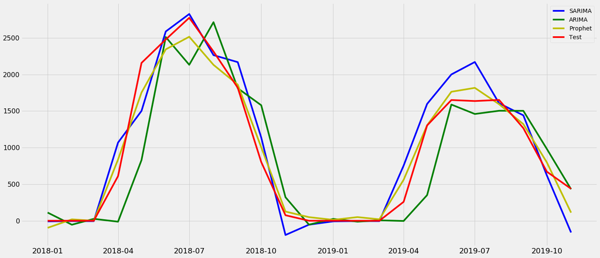

```python
plt.figure(figsize=(22, 10))
plt.plot(sarima_y_forecasted.index, sarima_y_forecasted, label='SARIMA', color='b')
plt.plot(arima_y_forecasted.index, arima_y_forecasted, label='ARIMA', color='g')
plt.plot(q1_forecast['ds'][91:114], q1_forecast['yhat'][91:114], label='Prophet', color='y')
plt.plot(test.index, test, label='Test', color='r')
plt.legend(loc='best', fontsize='medium')
plt.xticks(fontsize=18)
plt.yticks(fontsize=16)
plt.show()
```

### Conclusion for performance of 3 models:

- ARIMA is under-performance, and it is not able to predict the seasonality trend.
- SARIMA is over-performance, and it is able to predict the seasonality trend.
- FB Prophet is fitted, and it is able to predict the seasonality trend. This is the best model out of three.

## So we will use FB prophet to predict the future outlook of Nice Ride Minnesota service

## Prediction usage for future years

```python
# Predict what will happen in 2020 how many people will use the services
q1_forecast_2020 = forecast_value[114:]
q1_forecast_2020.head(12)
```

|  | ds | yhat |
| --- | --- | --- |
| 114 | 2019-12-01 | -3.128951 |
| 115 | 2020-01-01 | 1.439807 |
| 116 | 2020-02-01 | 42.960297 |
| 117 | 2020-03-01 | -6.568913 |
| 118 | 2020-04-01 | 452.842067 |
| 119 | 2020-05-01 | 925.139933 |
| 120 | 2020-06-01 | 1093.154849 |
| 121 | 2020-07-01 | 1225.314057 |
| 122 | 2020-08-01 | 1044.028550 |
| 123 | 2020-09-01 | 838.647866 |
| 124 | 2020-10-01 | 498.857804 |
| 125 | 2020-11-01 | 45.657675 |

```python
# Minor preprocessing values for 2020 dataset
q1_forecast_2020['yhat'].loc[(q1_forecast_2020['yhat'] < 0)] = 0
q1_forecast_2020.head(12)
```

|  | ds | yhat |
| --- | --- | --- |
| 114 | 2019-12-01 | 0.000000 |
| 115 | 2020-01-01 | 1.439807 |
| 116 | 2020-02-01 | 42.960297 |
| 117 | 2020-03-01 | 0.000000 |
| 118 | 2020-04-01 | 452.842067 |
| 119 | 2020-05-01 | 925.139933 |
| 120 | 2020-06-01 | 1093.154849 |
| 121 | 2020-07-01 | 1225.314057 |
| 122 | 2020-08-01 | 1044.028550 |
| 123 | 2020-09-01 | 838.647866 |
| 124 | 2020-10-01 | 498.857804 |
| 125 | 2020-11-01 | 45.657675 |

```python
# Calculate number of riderships in 2020
q1_forecast_2020['yhat'].mean()
```

```
514.0035753474972
```

```python
# Recalling back the average riderships from previous year from 2010-2019
q1_res.head(12)
```

```
Date
2010-01-01     474.0
2011-01-01     597.0
2012-01-01     750.0
2013-01-01     846.0
2014-01-01    1138.0
2015-01-01    1324.0
2016-01-01    1181.0
2017-01-01    1262.0
2018-01-01    1093.0
2019-01-01     849.0
Freq: AS-JAN, Name: Number of Biker, dtype: float64
```

# Question 2

*2) What is the typical duration of a trip? Should we change how we charge people, either per trip or by duration?*

## EDA

```python
train_data = data_from2010.copy()
test_data = data_from2018.copy()

print('Training data 2010-17')
train_data.info()
print('Testing data 2018-19')
test_data.info()
```

```
Training data 2010-17
<class 'pandas.core.frame.DataFrame'>
Int64Index: 2694251 entries, 0 to 460717
Data columns (total 7 columns):
 #   Column                    Dtype
---  ------                    -----
 0   Start date                object
 1   Start station             object
 2   End date                  object
 3   End station               object
 4   Total duration (Seconds)  float64
 5   Account type              object
 6   Date                      object
dtypes: float64(1), object(6)
memory usage: 164.4+ MB
Testing data 2018-19
<class 'pandas.core.frame.DataFrame'>
RangeIndex: 662149 entries, 0 to 662148
Data columns (total 8 columns):
 #   Column              Non-Null Count   Dtype
---  ------              --------------   -----
 0   start_time          662149 non-null  object
 1   start station name  662149 non-null  object
 2   end_time            662149 non-null  object
 3   end station name    662149 non-null  object
 4   tripduration        662149 non-null  int64
 5   usertype            662149 non-null  object
 6   bike type           662149 non-null  object
 7   Date                662149 non-null  object
dtypes: int64(1), object(7)
memory usage: 40.4+ MB
```

### Duration Analysis

```python
# Extract total duration columns.
x = train_data['Total duration (Seconds)'].sort_values(ascending = True)
duration_list = x.values.tolist()
```

```
Unrestricted Durations
```

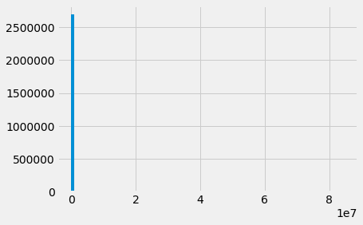

```python
unrestricted = [values for values in duration_list]
print('Unrestricted Durations')
plt.hist(unrestricted, bins = 100)
plt.show()
```

This histogram is very difficult to interpret. There some extreme outliers within the dataset.

```
30s < Durations < 1hr, Removed: 162679
```

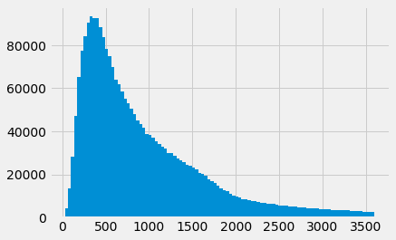

```python
gt30s_lt1h = [values for values in duration_list if values < 60*60 and values > 30]
print('30s < Durations < 1hr, Removed:', len(duration_list) - len(gt30s_lt1h))
plt.hist(gt30s_lt1h, bins = 100)
plt.show()
```

```
Durations < 1hr, Removed: 147775
```

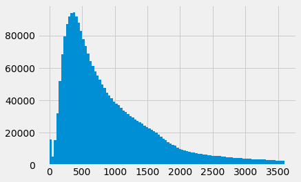

```python
lt1h = [values for values in duration_list if values < 60*60]
print('Durations < 1hr, Removed:', len(duration_list) - len(lt1h))
plt.hist(lt1h, bins = 100)
plt.show()
```

Simple arithmetic shows us that there are approximately 15,000 data points with durations less than 30 seconds. It is possible they are actually being used for that length, but it seems improbable. That would be a very quick ride.

```
Durations < 10hr, Removed: 7322
```

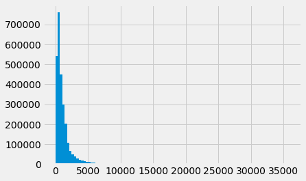

```python
lt10h = [values for values in duration_list if values < 60*60*10]
print('Durations < 10hr, Removed:', len(duration_list) - len(lt10h))
plt.hist(lt10h, bins = 100)
plt.show()
```

This histogram illustrates even better the outliers of the data set. That there are more than 7,000 rides with durations greater than 10 hours. The only option I could believe is an cyclist ultramarathon.

```
Durations < 100s, Removed: 2662452
```

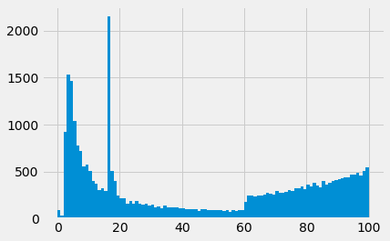

```python
lt100s = [values for values in duration_list if values < 100]
print('Durations < 100s, Removed:', len(duration_list) - len(lt100s))
plt.hist(lt100s, bins = 100)
plt.show()
```

This illustrates our lower bound outliers. There is a very strange spike around 5 seconds and 17 seconds. These seem like hardly enough time to release, get on, ride to a destination, get off, and return a bike. There is also a significant increase at the one minute bar.

Through this analysis, we've interpreted these outliers to mean there are problems or issues with the Nice Ride system metrics. For this question, we will ignore rides with durations less than one minute and greater than 6 hours. As well as the outliers from before or after a season starts and ends.

# Create the dateframes

```python
# Copy our dataframes
q2_train = data_from2010.copy()
print('Data from 2010 thru 2017')
q2_train.info(verbose = True, null_counts = True)
```

```
Data from 2010 thru 2017
<class 'pandas.core.frame.DataFrame'>
Int64Index: 2694251 entries, 0 to 460717
Data columns (total 7 columns):
 #   Column                    Non-Null Count    Dtype
---  ------                    --------------    -----
 0   Start date                2694251 non-null  object
 1   Start station             2694251 non-null  object
 2   End date                  2694251 non-null  object
 3   End station               2694251 non-null  object
 4   Total duration (Seconds)  2694251 non-null  float64
 5   Account type              2694251 non-null  object
 6   Date                      2694251 non-null  object
dtypes: float64(1), object(6)
memory usage: 164.4+ MB
```

```python
q2_test = data_from2018.copy()
print('Data from 2018 thru 2019')
q2_test.info(verbose = True, null_counts = True)
```

```
Data from 2018 thru 2019
<class 'pandas.core.frame.DataFrame'>
RangeIndex: 662149 entries, 0 to 662148
Data columns (total 8 columns):
 #   Column              Non-Null Count   Dtype
---  ------              --------------   -----
 0   start_time          662149 non-null  object
 1   start station name  662149 non-null  object
 2   end_time            662149 non-null  object
 3   end station name    662149 non-null  object
 4   tripduration        662149 non-null  int64
 5   usertype            662149 non-null  object
 6   bike type           662149 non-null  object
 7   Date                662149 non-null  object
dtypes: int64(1), object(7)
memory usage: 40.4+ MB
```

```python
# Extract Date and Total durations columns:
q2_train = q2_train[['Date','Total duration (Seconds)']]
q2_test = q2_test[['Date','tripduration']]

## Convert Date columns to datetime for FB Prophet
q2_train['Date'] = pd.to_datetime(q2_train['Date'])
q2_test['Date'] = pd.to_datetime(q2_test['Date'])
```

### Merge dataframes from 2010-2019

```python
# Change columns name of trip duration of testing data
q2_test = q2_test.rename(columns={'tripduration': 'Total duration (Seconds)'})

q2_df = q2_train.append(q2_test)
```

# Model

```python
# Thresholds to remove outliers
minimum = 60           # 1 minute
maximum = 60 * 60 * 6  # 6 hours

# Partially mechanically determined and by hand
season_dates = {'2010':['2010-06-01', '2010-11-07'],
                '2011':['2011-04-07', '2011-11-06'],
                '2012':['2012-04-02', '2012-11-04'],
                '2013':['2013-04-03', '2013-11-03'],
                '2014':['2014-04-11', '2014-11-02'],
                '2015':['2015-04-01', '2015-11-01'],
                '2016':['2016-04-04', '2016-11-06'],
                '2017':['2017-04-03', '2017-11-05'],
                '2018':['2018-04-28', '2018-11-17'],
                '2019':['2019-04-28', '2019-11-17']}

def make_q2mod_df(df, resamp_freq, resamp_flag):
    temp = df.set_index('Date')

    # Remove outliers
    temp = temp[temp['Total duration (Seconds)'] >= minimum]
    temp = temp[temp['Total duration (Seconds)'] <= maximum]

    # Resample
    if resamp_flag:
        temp = temp['Total duration (Seconds)'].resample(resamp_freq).mean()
    else:
        temp = pd.Series(temp['Total duration (Seconds)'])

    # Remove weird data from before seasons' start and after thier end
    ts = pd.Series()
    for key in season_dates:
        mask = (temp.index >= season_dates[key][0]) & (temp.index <= season_dates[key][1])
        ts = ts.append(temp.loc[mask])

    return pd.DataFrame({'ds':ts.index, 'y':ts}).reset_index().drop('index', axis = 1).dropna(0)

# Create the training and test sets, and resample
q2mod_df_train = make_q2mod_df(q2_train, 'D', True)
q2mod_df_test = make_q2mod_df(q2_test, 'D', True)
```

```python
q2mod = Prophet(interval_width = 0.95,
                seasonality_mode = 'multiplicative',
                yearly_seasonality = True,
                weekly_seasonality = True).add_country_holidays(country_name = 'US').fit(q2mod_df_train)
# additional parameters:
#  changepoint_prior_scale = 0.5
#  changepoint_range = 1.0
#  changepoints = chg_points
#  daily_seasonality = True        # add back if changed to hourly averages
# .add_seasonality(name='monthly',
#                  period=30.5,
#                  fourier_order=12) # The granularity of the curve, higher more curves, etc
```

```
INFO:fbprophet:Disabling daily seasonality. Run prophet with daily_seasonality=True to override this.
```

I could see holidays having a positive or negative effect. The positive effect would be people are free from work or school and can use a bike when they otherwise would not need or be able to use one. The negative effect would be people don't have to work so they don't need to ride to work or school and could stay home therefore not needing to use the bikes.

```python
# Create our own dataframe with the correct test and forecast dates
q2future = q2mod_df_train['ds']
q2future = q2future.append(q2mod_df_test['ds']).reset_index().drop('index', axis = 1)

q2forecast = q2mod.predict(q2future)
```

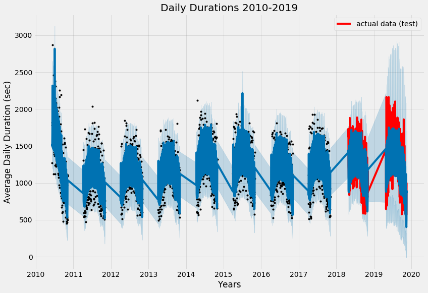

```python
fig, ax = plt.subplots(figsize=(12, 8))
ax.plot(q2mod_df_test.set_index('ds'), color = 'red', label = 'actual data (test)')
fig = q2mod.plot(q2forecast, uncertainty = True, ax = ax)

ax.set_title('Daily Durations 2010-2019')
ax.set_xlabel('Years')
ax.set_ylabel('Average Daily Duration (sec)')
ax.legend()
```

It seems like the Prophet predictions and forecasts are close to the actually datasets. There is a strange spike in 2015. Unsure how to characterize it.

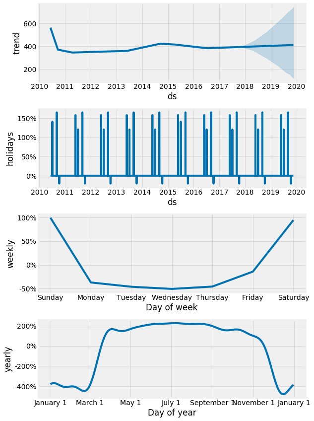

```python
fig2 = q2mod.plot_components(q2forecast)
```

```python
q2mod_forecast = q2forecast[['ds', 'yhat']]
q2mod_forecast = q2mod_forecast[q2mod_forecast['ds'] > '2018']

## Check on performance of model by calculating MSE and RMSE
mse = mean_squared_error(q2mod_df_test['y'], q2mod_forecast['yhat'], squared = False)

print('The Mean Squared Error is {}'.format(round(mse, 2)))
print('The Root Mean Squared Error is {}'.format(round(np.sqrt(mse), 2)))
```

```
The Mean Squared Error is 196.4
The Root Mean Squared Error is 14.01
```

# What is the typical duration of a trip? Should we change how we charge people, either per trip or by duration?

```python
# Make our dataframes without sampling
q2_all_durations_train = make_q2mod_df(q2_train, '', False)
q2_all_durations_test = make_q2mod_df(q2_test, '', False)
```

```python
total_rides = q2_all_durations_train['y'].count() + q2_all_durations_test['y'].count()
total_time = q2_all_durations_train['y'].sum() + q2_all_durations_test['y'].sum()
total_time_str = str(datetime.timedelta(seconds = total_time))
print(' Rides:', total_rides, '\n',
      'Total duration:', total_time_str, '\n',
      'Average ride duration:', round(total_time / total_rides / 60, 2), 'minutes')
```

```
 Rides: 3305274
 Total duration: 47252 days, 7:41:52.973000
 Average ride duration: 20.59 minutes
```

Given our prior assumptions--removing extremely short and long rides along with unseasonal rides--from 2010 through 2019 Nice Ride Minnesota has had *over 3 million instances of bike use* this use equates to more than *47,000 days*.

## 2020 Prediction

```python
# Create dataframe with all our data to predict 2020
q2mod_df_all = q2mod_df_train.append(q2mod_df_test).reset_index()

q2mod2020 = Prophet(interval_width = 0.95,
                    seasonality_mode = 'multiplicative',
                    yearly_seasonality = True,
                    weekly_seasonality = True).add_country_holidays(country_name = 'US').fit(q2mod_df_all)
```

```
INFO:fbprophet:Disabling daily seasonality. Run prophet with daily_seasonality=True to override this.
```

```python
# Append 2020 forecast dates
q2future2020 = q2future.append(pd.DataFrame({'ds':pd.date_range(start = '2020-04-01', end = '2020-11-10')})).reset_index().drop('index', axis = 1)

# Forecast 2020
q2forecast2020 = q2mod.predict(q2future2020)
```

```
WARNING:matplotlib.legend:No handles with labels found to put in legend.
```

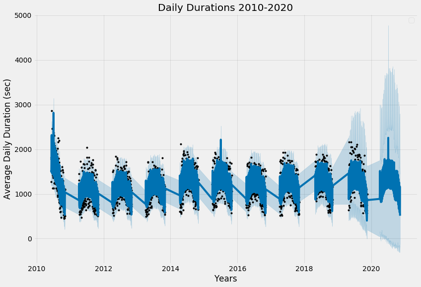

```python
fig, ax = plt.subplots(figsize = (12, 8))
#ax.plot(q2mod_df_all.set_index('ds'), color = 'red', label = 'actual data')
fig = q2mod2020.plot(q2forecast2020, uncertainty = True, ax = ax)

ax.set_title('Daily Durations 2010-2020')
ax.set_xlabel('Years')
ax.set_ylabel('Average Daily Duration (sec)')
ax.legend()
```

There is the same strange spike in data as from 2015, but forecast doesn't look too far from the trending data.

```python
#q2_all_durations = q2_all_durations_train.copy()
#q2_all_durations = q2_all_durations.append(q2_all_durations_test, ignore_index = True)
#q2_all_durations = q2_all_durations.reset_index().drop('index', axis = 1)
#q2_all_durations = q2_all_durations[q2_all_durations['ds'] >= '2019']
#q2_all_durations = q2_all_durations[q2_all_durations['ds'] < '2019']
#q2_all_durations.count()
```

```python
q2forecast2020only = q2forecast2020[['ds', 'yhat']]
q2forecast2020only = q2forecast2020only[q2forecast2020only['ds'] > '2020']

gt30 = q2forecast2020only[q2forecast2020only['yhat'] >= 30*60]
total_time = q2forecast2020only['yhat'].sum()
total_time_str = str(datetime.timedelta(seconds = total_time))
average_duration = total_time / q2forecast2020only.count()
print(' Total duration:', round(total_time, 2), 'seconds or', total_time_str, '\n',
      'Average ride duration by day:', round(average_duration['yhat'] / 60, 2), 'minutes\n',
      'Durations over 30 minutes:', gt30['yhat'].count())
gt30
```

```
 Total duration: 267127.08 seconds or 3 days, 2:12:07.077837
 Average ride duration by day: 19.88 minutes
 Durations over 30 minutes: 2
```

|  | ds | yhat |
| --- | --- | --- |
| 2138 | 2020-07-03 | 1886.547317 |
| 2139 | 2020-07-04 | 2256.871604 |

## Nice Ride Pricing Plans

Referencing Nice Rides website at https://www.niceridemn.com/pricing, their plans are as follows:

- Single rides, up to 30 minutes \$2 per trip
- Day Pass, unlimited 30-minute rides in a 24-hour period \$6 per day
- Annual membership, unlimited 60-minute rides for 365 days \$75 per year

## Question 2 Conclusion

Our forecast shows the average rider is not increasing their duration past the 30-minute limit. There are 2 days where this average duration exceeds the 30-minute limit. From the above table, they appear to be in the prime summer months. The Day Pass seems to be an excellent value for the customer during those days and would be the equivalent of three Single ride passes. The Annual membership equates to 37.5 Single passes or 12.5 Day passes. Nice Ride could see an increase in revenue, but at the possible expense of customer goodwill. Given Nice Ride's historical data and the assumption that their business model is promoting their goals, mission, and values we see no indication that they should change their pricing plan.

Nice Ride should keep how they currently charge people:

- Single Ride
- Day Pass
- Annual Membership

# Question 3

*What stations are the most frequent starting points for trips? Should we add more bikes at the frequen starting point or should we remove bikes in at the frequent starting point?*

## EDA

Let us review the most used and least used stations

```python
train_q3 = data_from2010.copy()
test_q3 = data_from2018.copy()
```

```python
#only keep columns needed
test1_q3 = test_q3[['Date', 'start station name']]
train1_q3 = train_q3[['Date', 'Start station']]

#rename test columns so we can concatenate for one time through data manipulation before splitting again
test1_q3 = test1_q3.rename(columns={"start station name": "Start station"})

#concatenate
frames = [train1_q3, test1_q3]
df = pd.concat(frames, keys=['train', 'test'])
```

### Most used and Least Used Stations

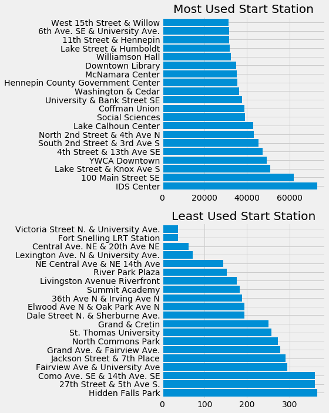

```python
counts_top = train_q3['Start station'].value_counts().head(20)
counts_low = train_q3['Start station'].value_counts().tail(20)

fig, (ax1,ax2) = plt.subplots(2,1, figsize=(10,7))

counts_top.plot(kind = 'barh', figsize = (8, 10), zorder = 2, width = 0.85, ax = ax1)
counts_low.plot(kind = 'barh', figsize = (8, 10), zorder = 2, width = 0.85, ax = ax2)

ax1.set_title('Most Used Start Station')
ax2.set_title('Least Used Start Station')

plt.tight_layout()
```

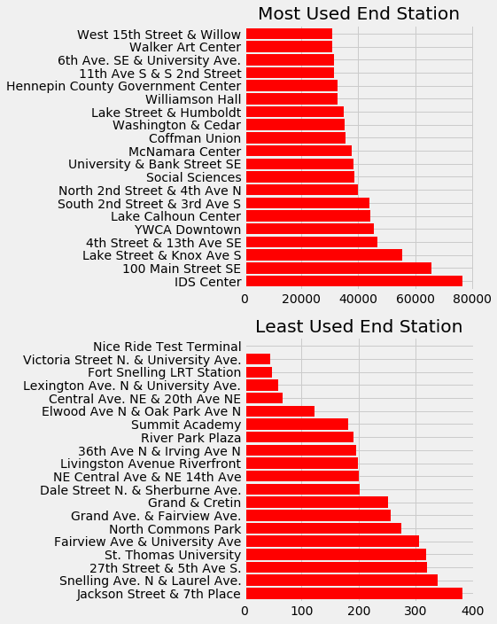

```python
counts_top_end = train_q3['End station'].value_counts().head(20)
counts_low_end = train_q3['End station'].value_counts().tail(20)

fig, (ax1, ax2) = plt.subplots(2, 1)

counts_top_end.plot(kind = 'barh', figsize = (8, 10), zorder = 2, color = 'red', width = 0.85,
                    ax = ax1)
counts_low_end.plot(kind = 'barh', figsize = (8, 10), zorder = 2, color = 'red', width = 0.85,
                    ax = ax2)

ax1.set_title('Most Used End Station')
ax2.set_title('Least Used End Station')
plt.tight_layout()
```

### Data Manipulation

```python
#Change date column to datetime
df['Date'] = pd.to_datetime(df['Date'])
```

```python
# Manipulate data to get frequency of trips per station per day
df_ss = df.groupby(['Date', 'Start station']).size().to_frame(name = 'freq').reset_index()
df_ss
```

|  | Date | Start station | freq |
| --- | --- | --- | --- |
| 0 | 2010-06-07 | Mayo Building | 1 |
| 1 | 2010-06-08 | Walker Art Center | 1 |
| 2 | 2010-06-08 | YWCA Downtown | 1 |
| 3 | 2010-06-09 | 11th Street & Marquette | 3 |
| 4 | 2010-06-09 | 25th Street & 33rd Ave S | 1 |
| ... | ... | ... | ... |
| 288038 | 2019-11-17 | West 15th Street & Willow | 2 |
| 288039 | 2019-11-17 | West 34th Street & Hennepin Ave S | 1 |
| 288040 | 2019-11-17 | Willey Hall | 2 |
| 288041 | 2019-11-17 | YWCA Downtown | 6 |
| 288042 | 2019-11-17 | YWCA Uptown | 3 |

288043 rows × 3 columns

```python
#pivot the table so start stations are columns, dates are indexes and the values are frequencies
df_ss2 = df_ss.pivot(index ='Date', columns ='Start station', values = 'freq')
df_ss2.reset_index(inplace=True)
```

```python
#Check data types
# df_ss2.dtypes
```

```python
#Fill Nulls with 0's
df_ss2=df_ss2.fillna(0)
# df_ss2
```

```python
#sort and only keep top 4 start stations
df_4  = df_ss2[['Date', 'IDS Center', '100 Main Street SE',
                 'Lake Street & Knox Ave S', 'YWCA Downtown']]

df_4
```

| Start station | Date | IDS Center | 100 Main Street SE | Lake Street & Knox Ave S | YWCA Downtown |
| --- | --- | --- | --- | --- | --- |
| 0 | 2010-06-07 | 0.0 | 0.0 | 0.0 | 0.0 |
| 1 | 2010-06-08 | 0.0 | 0.0 | 0.0 | 1.0 |
| 2 | 2010-06-09 | 0.0 | 0.0 | 0.0 | 3.0 |
| 3 | 2010-06-10 | 5.0 | 3.0 | 0.0 | 5.0 |
| 4 | 2010-06-11 | 10.0 | 32.0 | 0.0 | 20.0 |
| ... | ... | ... | ... | ... | ... |
| 2079 | 2019-11-13 | 0.0 | 1.0 | 0.0 | 8.0 |
| 2080 | 2019-11-14 | 0.0 | 1.0 | 0.0 | 9.0 |
| 2081 | 2019-11-15 | 0.0 | 2.0 | 0.0 | 11.0 |
| 2082 | 2019-11-16 | 0.0 | 2.0 | 9.0 | 6.0 |
| 2083 | 2019-11-17 | 0.0 | 1.0 | 1.0 | 6.0 |

2084 rows × 5 columns

```python
#create each time series/// seperate into train and test //// rename titles to run
# train data 6/10/2010 ---> 04/03/2017
# test data 2018-04-24 ---> 2019-11-30
# test data 1679=<.... train date  <1679

#Top 3
df_T1 = df_4[['Date', 'IDS Center']]
df_T1_train =  df_T1.iloc[:1679]
df_T1_test = df_T1.iloc[1679:-1]
df_T1_test['Date'] = pd.to_datetime(df_T1_test['Date'])

df_T2 = df_4[['Date', '100 Main Street SE']]
df_T2_train =  df_T2.iloc[:1679]
df_T2_test = df_T2.iloc[1679:-1]
df_T2_test['Date'] = pd.to_datetime(df_T2_test['Date'])

df_T3 = df_4[['Date', 'Lake Street & Knox Ave S']]
df_T3_train =  df_T3.iloc[:1679]
df_T3_test = df_T3.iloc[1679:-1]
df_T3_test['Date'] = pd.to_datetime(df_T3_test['Date'])

df_T4 = df_4[['Date', 'YWCA Downtown']]
df_T4_train =  df_T4.iloc[:1679]
df_T4_test = df_T4.iloc[1679:-1]
df_T4_test['Date'] = pd.to_datetime(df_T4_test['Date'])
```

# Model

```python
# From: https://www.digitalocean.com/community/tutorials/a-guide-to-time-series-forecasting-with-prophet-in-python-3
plt.style.use('fivethirtyeight')
```

```python
#------ Change column names to match FB prophet requirements -------
#Top 4
df_T1_train_fb = df_T1_train.rename(columns={'Date': 'ds',
                        'IDS Center': 'y'})
df_T2_train_fb = df_T2_train.rename(columns={'Date': 'ds',
                        '100 Main Street SE': 'y'})
df_T3_train_fb = df_T3_train.rename(columns={'Date': 'ds',
                        'Lake Street & Knox Ave S': 'y'})
df_T4_train_fb = df_T4_train.rename(columns={'Date': 'ds',
                        'YWCA Downtown': 'y'})

# df_T1_train_fb
```

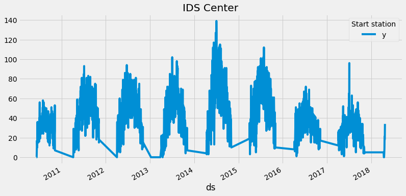

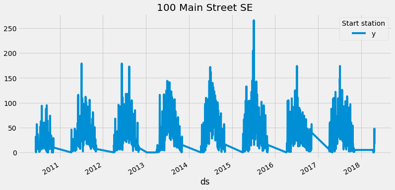

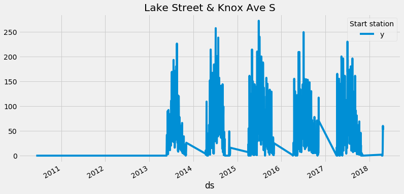

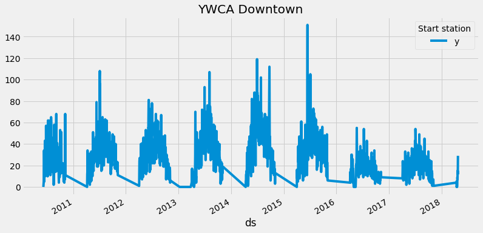

```python
# graph data
pd.plotting.register_matplotlib_converters() #fix: float() argument must be a string or a number, not 'Period'

df_T1_train_fb.set_index('ds').plot(figsize=(12, 6), title ='IDS Center')
df_T2_train_fb.set_index('ds').plot(figsize=(12, 6), title ='100 Main Street SE')
df_T3_train_fb.set_index('ds').plot(figsize=(12, 6), title ='Lake Street & Knox Ave S')
df_T4_train_fb.set_index('ds').plot(figsize=(12, 6), title ='YWCA Downtown')

plt.show()
```

```python
#------ set the uncertainty interval to 95% (the Prophet default is 80%)
my_model_T1 = Prophet(seasonality_mode='multiplicative',weekly_seasonality=True,
                      daily_seasonality=True,interval_width=0.95)
my_model_T2 = Prophet(seasonality_mode='multiplicative',weekly_seasonality=True,
                      daily_seasonality=True,interval_width=0.95)
my_model_T3 = Prophet(seasonality_mode='multiplicative',weekly_seasonality=True,
                      daily_seasonality=True,interval_width=0.95)
my_model_T4 = Prophet(seasonality_mode='multiplicative',weekly_seasonality=True,
                      daily_seasonality=True,interval_width=0.95)
```

```python
#------- fit the data -----
my_model_T1.fit(df_T1_train_fb)
my_model_T2.fit(df_T2_train_fb)
my_model_T3.fit(df_T3_train_fb)
my_model_T4.fit(df_T4_train_fb)
```

```
<fbprophet.forecaster.Prophet at 0x28ec3cee148>
```

```python
future_dates_T1 = my_model_T1.make_future_dataframe(periods=16, freq='MS')
future_dates_T2 = my_model_T2.make_future_dataframe(periods=16, freq='MS')
future_dates_T3 = my_model_T3.make_future_dataframe(periods=16, freq='MS')
future_dates_T4 = my_model_T4.make_future_dataframe(periods=16, freq='MS')
```

```python
#-----forecast-----
forecast_T1 = my_model_T1.predict(future_dates_T1)
forecast_T2 = my_model_T2.predict(future_dates_T2)
forecast_T3 = my_model_T3.predict(future_dates_T3)
forecast_T4 = my_model_T4.predict(future_dates_T4)
```

## IDS Center

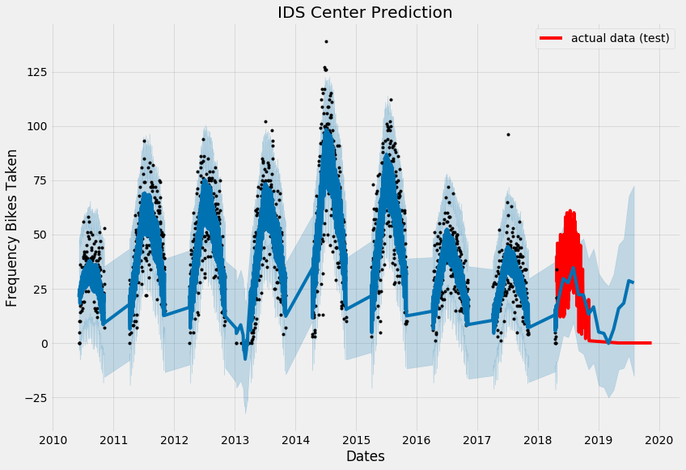

```python
#------ Graph actual data vs forecasts data with confidence intervals ------
fig, ax = plt.subplots(figsize=(12, 8))
ax.plot(df_T1_test.set_index('Date'), color= 'red', label='actual data (test)')
fig= my_model_T1.plot(forecast_T1, uncertainty=True, ax=ax)

ax.set_title('IDS Center Prediction')
ax.set_xlabel('Dates')
ax.set_ylabel('Frequency Bikes Taken')

ax.legend()
```

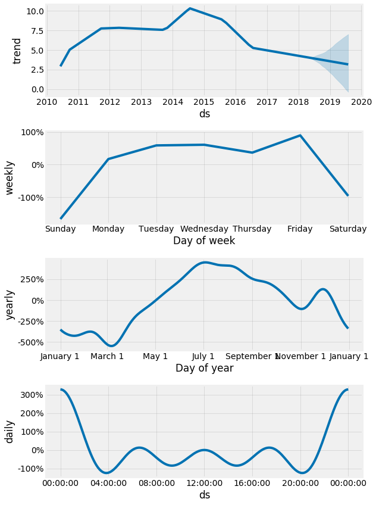

```python
fig2 = my_model_T1.plot_components(forecast_T1)
```

## 100 Main Street SE

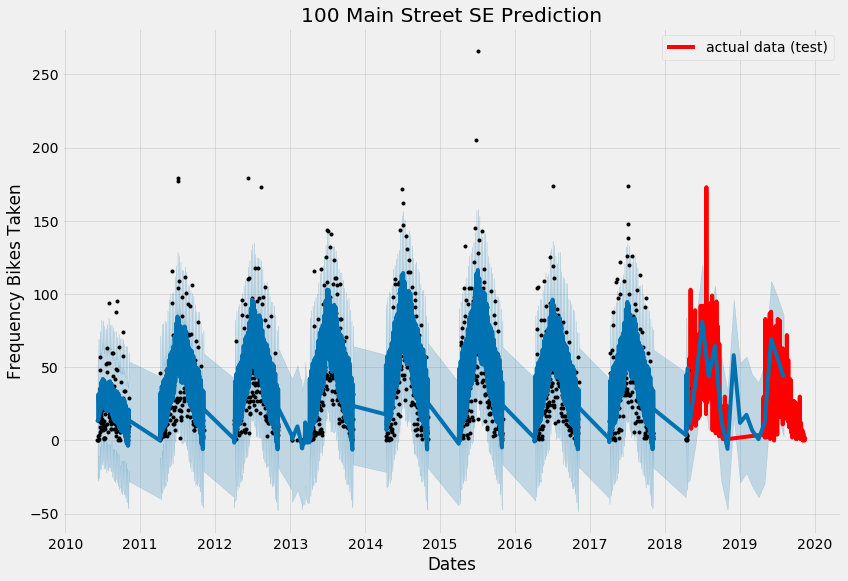

```python
#------ Graph actual data vs forecasts data with confidence intervals ------
fig, ax = plt.subplots(figsize=(12, 8))
ax.plot(df_T2_test.set_index('Date'), color= 'red', label='actual data (test)')
fig= my_model_T2.plot(forecast_T2, uncertainty=True, ax=ax)

ax.set_title('100 Main Street SE Prediction')
ax.set_xlabel('Dates')
ax.set_ylabel('Frequency Bikes Taken')

ax.legend()
```

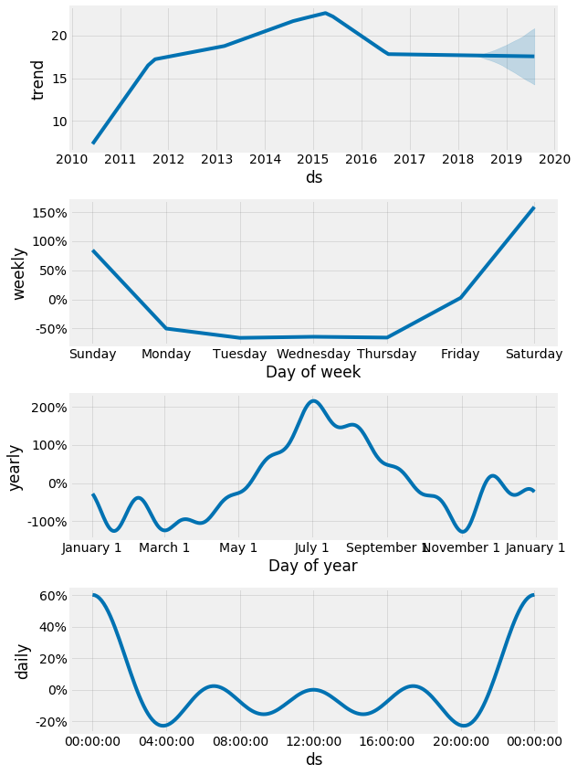

```python
fig2 = my_model_T2.plot_components(forecast_T2)
```